# Blog #3

Shaya Engelman

2024-05-07

Title: Unleashing the Power of Transformations in R for Enhanced Data Analysis

In the realm of data analysis, transforming variables can often unlock valuable insights and improve model performance. One powerful technique in this regard is power transformations. In this blog post, we’ll explore what power transformations are, why they’re useful, and how to implement them in R. We’ll also provide dummy data examples and R snippets to illustrate the concepts.

### Understanding Power Transformations

Power transformations involve raising each observation in a variable to a power, typically less than one. The most common power transformations include square root, cube root, and the natural logarithm.

### Why Use Power Transformations?

1. **Normalization**: Power transformations can help make data more normally distributed, which is often a requirement for certain statistical techniques.
2. **Stabilization of Variance**: Power transformations can stabilize the variance of the data, making it more homoscedastic and suitable for linear modeling.
3. **Outlier Handling**: Power transformations can mitigate the impact of outliers by shrinking extreme values towards the center of the distribution.
4. **Interpretability**: In some cases, power transformations can make relationships between variables more interpretable by linearizing non-linear relationships.

### Dummy Data Example

Let’s create some dummy data to illustrate the concepts discussed:

```r
# Generating dummy data
set.seed(123)
n <- 1000  # Total number of samples
data <- data.frame(
  x = rchisq(n, df = 5),  # Chi-squared distribution
  y = rnorm(n, mean = 10, sd = 3)  # Normal distribution
)
```

In this example, we have two variables, `x` following a chi-squared distribution and `y` following a normal distribution.

### Implementing Power Transformations

#### Square Root Transformation

```r
# Square root transformation
data$sqrt_x <- sqrt(data$x)
```

#### Cube Root Transformation

```r
# Cube root transformation
data$root_x <- data$x^(1/3)
```

#### Natural Logarithm Transformation

```r
# Natural logarithm transformation
data$log_y <- log(data$y)
```

### Visualizing Transformations

Let’s visualize the transformations to see their effects:

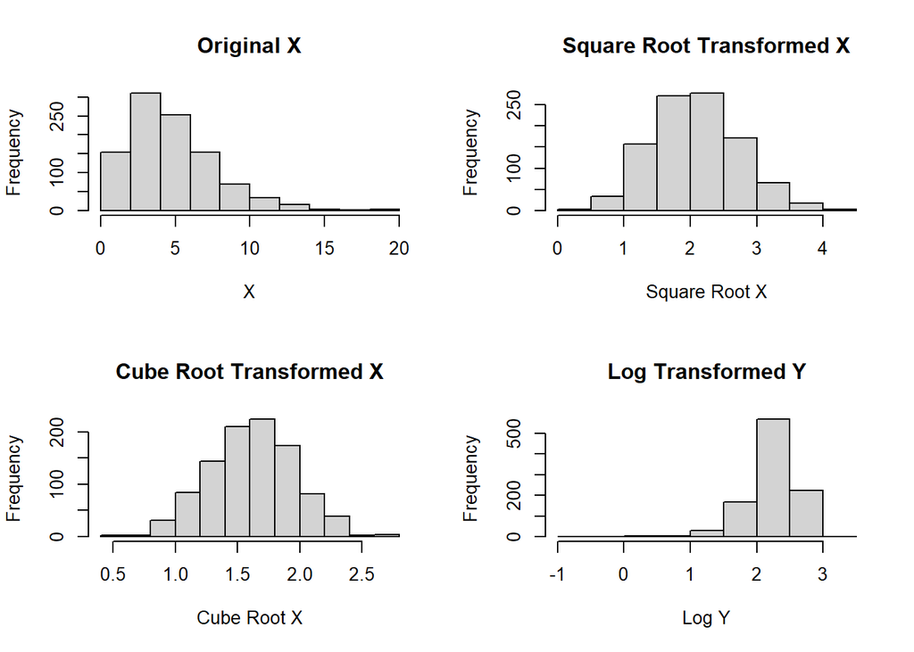

```r
# Visualizing transformations
par(mfrow = c(2, 2))
hist(data$x, main = "Original X", xlab = "X")
hist(data$sqrt_x, main = "Square Root Transformed X", xlab = "Square Root X")
hist(data$root_x, main = "Cube Root Transformed X", xlab = "Cube Root X")
hist(data$log_y, main = "Log Transformed Y", xlab = "Log Y")
```

### Conclusion

Power transformations offer a versatile tool for data analysts and researchers to preprocess data, improve model performance, and enhance interpretability. By understanding the concepts behind power transformations and implementing them effectively in R, we can unlock hidden patterns and relationships in our data.

In this blog post, we’ve explored the basics of power transformations, their benefits, and how to implement them using R. Through dummy data examples and R snippets, we’ve demonstrated the power of transformations in action. Whether it’s normalizing distributions, stabilizing variance, or enhancing interpretability, power transformations empower us to extract deeper insights from our data and drive more informed decision-making.